# Análise - Pesquisa Star Wars

Amanda Provetti

```r
library(tidyverse)
library(ggplot2)
library(fastDummies)
library(caret)
library(corrplot)
library(RColorBrewer)
```

O dataset foi construído baseado em uma entrevista realizada com 1186 pessoas sobre a saga Star Wars. O arquivo contém dados relacionados com questões como: “Você já viu o filme?”, “Você se considera um fã?”, além da relação de filmes, nota de cada filme, familiaridade com determinados personagens, sobre ser um fã da saga Star Trek e dados pessoais do entrevistado, como faixa etária, região onde mora, gênero, escolaridade e renda. Abaixo seguem algumas análises e testes feitos acerca deste dataset. https://github.com/fivethirtyeight/data/tree/master/star-wars-survey

#### Tratamento do dataset para renomear as colunas de forma mais legível e remover a primeira linha que não contém informações relevantes.

```r
dataset = read.csv("StarWars.csv", sep = ",", na.strings=c("","NA"), skip = 1)
cols_names <- c("id", "seen", "is_fan", "ep1", "ep2", "ep3", "ep4", "ep5", "ep6", "note_ep1", "note_ep2", "note_ep3", "note_ep4", "note_ep5", "note_ep6", "state_han", "state_luke", "state_leia", "state_anakin", "state_obi", "state_emperor", "state_darth", "state_lando", "state_boba", "state_c3po", "state_r2d2", "state_jar", "state_padime", "state_yoda", "shot_first", "familiar_ex_uni", "fan_exp_uni", "fan_star_trek", "gender", "age", "income", "education", "location")

colnames(dataset) <- cols_names
```

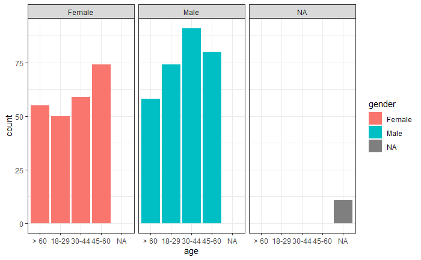

#### Análise de média de votos por cada filme da saga

```
numeric(0)
```

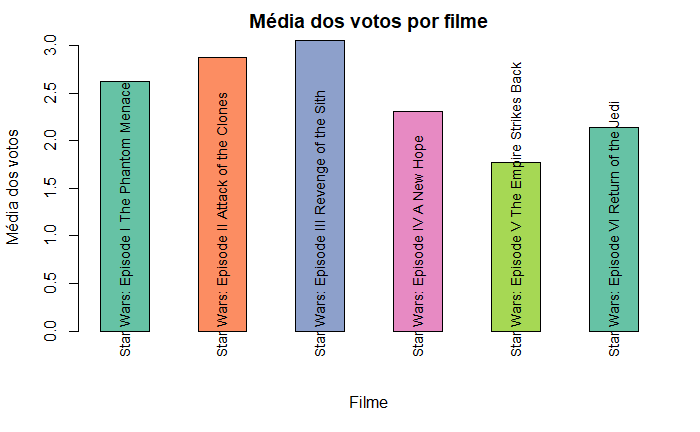

```r
dataset_movies <- dataset[,10:15]

cols <- colnames(dataset_movies)

df_movies_rank <- data.frame(matrix(nrow = 6, ncol =  2), stringsAsFactors = FALSE)

colnames(df_movies_rank) <- c("movie", "mean")

df_movies_rank$movie <- c("Star Wars: Episode I The Phantom Menace",
                          "Star Wars: Episode II Attack of the Clones",
                          "Star Wars: Episode III Revenge of the Sith",
                          "Star Wars: Episode IV A New Hope",
                          "Star Wars: Episode V The Empire Strikes Back",
                          "Star Wars: Episode VI Return of the Jedi")


for (i in 1:length(cols)) {
  col <- cols[i]
  df_movies_rank$mean[i] <- sum(as.integer(dataset_movies[[col]][2:nrow(dataset_movies)]), na.rm = TRUE) /     length(dataset_movies[[col]])
}

end_point = 0.5 + nrow(df_movies_rank) + nrow(df_movies_rank) - 1

coul <- brewer.pal(5, "Set2")

barplot(df_movies_rank$mean, xlab="Filme", ylab="Média dos votos",col=coul,
main="Média dos votos por filme",border="black", space = 1)+
text(seq(1.5, end_point, by = 2), par("usr")[3]-0.25,
     srt = 90, adj = 0, xpd = TRUE,
     labels = df_movies_rank$movie, cex = 0.85)
```

### Escolaridade dos entrevistados

```r
data_by_education <- dataset %>% group_by(education=dataset$education) %>% count()
```

```
Factor `education` contains implicit NA, consider using `forcats::fct_explicit_na`Factor `education` contains implicit NA, consider using `forcats::fct_explicit_na`
```

```r
data_by_education <- na.omit(data_by_education)
```

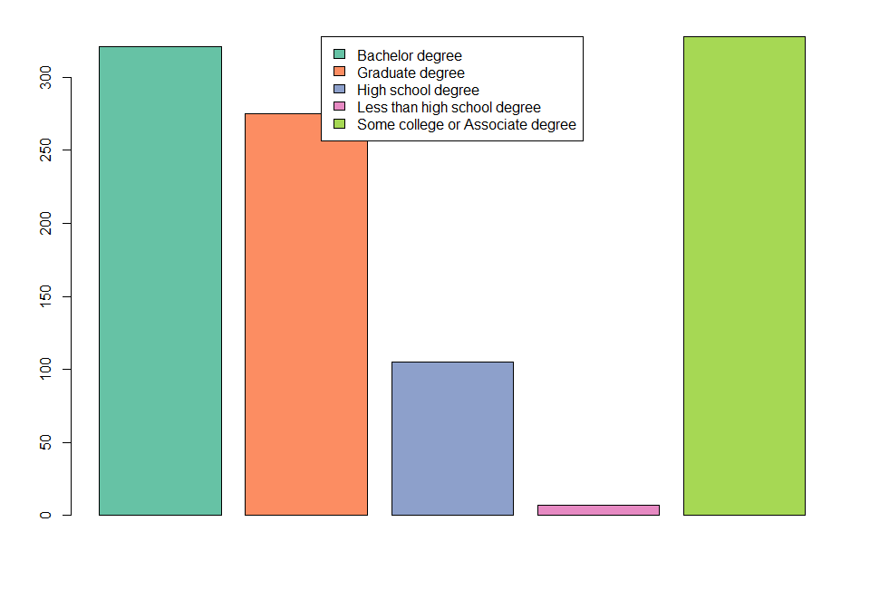

```r
coul <- brewer.pal(5, "Set2")


barplot(data_by_education$n, col=coul)
legend("top",
       legend = data_by_education$education,
       fill = coul)
```

#### Quantidade de pessoas que viram o filme por região ####

```r
table_1 <- with(dataset, table(location, seen))
table_1
```

[output not shown]

## Regressão logística baseada em ter visto filme

```r
binary <- dummy_cols(dataset, "seen", remove_selected_columns = TRUE)
afirmatives <- binary %>% select(seen_Yes)

n_df <- data.frame(seen=afirmatives$seen_Yes, gender=dataset$gender)
cols <- c("seen")
n_df[cols] <- lapply(n_df[cols], factor)
set.seed(100)
```

```r
indices_treinamento <- createDataPartition(n_df$seen, p = 0.7, list = FALSE)
dados_treinamento <-n_df[indices_treinamento,]
dados_teste <- n_df[-indices_treinamento,]
equation <- " seen ~ ."
equation <- as.formula(equation)
modelo_ML_logistic <- glm(equation, data = dados_treinamento, family = 'binomial')
```

```r
summary(modelo_ML_logistic)
```

[output not shown]

```r
previsao_teste <- predict(modelo_ML_logistic, dados_teste, type="response")
previsao_teste <- round(as.numeric(previsao_teste))
previsao_teste <- as.factor(previsao_teste)
```

#### Matriz de confusão dos dados de teste baseado em ter visto o filme e a gênero

```r
dados_teste_fatores = as.factor(dados_teste$seen)
previsao_teste_data <- data.frame(previsao_teste, dados_teste_fatores)
confusionMatrix(data = previsao_teste, reference = dados_teste_fatores, positive = "1")
```

[output not shown]

```r
binary_2 <- dummy_cols(dataset, "seen", remove_selected_columns = TRUE)
afirmatives_2 <- binary %>% select(seen_Yes)

n_df_2 <- data.frame(seen=afirmatives_2$seen_Yes, star_trek=dataset$fan_star_trek)
cols <- c("seen")
n_df_2[cols] <- lapply(n_df_2[cols], factor)
set.seed(100)
```

```r
indices_treinamento_2 <- createDataPartition(n_df_2$seen, p = 0.7, list = FALSE)
dados_treinamento_2 <-n_df_2[indices_treinamento_2,]
dados_teste_2 <- n_df_2[-indices_treinamento_2,]

modelo_ML_logistic_2 <- glm(seen ~ star_trek, data = dados_treinamento_2, family = 'binomial')
summary(modelo_ML_logistic_2)
```

[output not shown]

#### Matriz de confusão baseado em ter visto o filme e ser fã de Star Trek

```r
previsao_teste_2 <- predict(modelo_ML_logistic_2, dados_teste_2, type="response")
previsao_teste_2 <- round(as.numeric(previsao_teste_2))
previsao_teste_2 <- as.factor(previsao_teste_2)

dados_teste_fatores_2 = as.factor(dados_teste_2$seen)
previsao_teste_data_2 <- data.frame(previsao_teste_2, dados_teste_fatores_2)
confusionMatrix(data = previsao_teste_2, reference = dados_teste_fatores_2, positive = "1")
```

[output not shown]

## Testes baseados em Fãs de Star wars

```r
binary_3 <- dummy_cols(dataset, "is_fan", remove_selected_columns = TRUE)
afirmatives_3 <- binary_3 %>% select(is_fan_Yes)

n_df_3 <- data.frame(is_fan=afirmatives_3$is_fan_Yes, star_trek=dataset$fan_star_trek, age=dataset$age, gender=dataset$gender)
cols <- c("is_fan")
n_df_3[cols] <- lapply(n_df_3[cols], factor)
set.seed(100)
```

#### Modelo baseado em ser fã de Start wars, gênero, ser fã de Star Trek e idade

```r
indices_treinamento_3 <- createDataPartition(n_df_3$is_fan, p = 0.7, list = FALSE)
dados_treinamento_3 <-n_df_3[indices_treinamento_3,]
dados_teste_3 <- n_df_3[-indices_treinamento_3,]

modelo_ML_logistic_3 <- glm(is_fan ~ gender + star_trek + age, data = dados_treinamento_3, family = 'binomial')
summary(modelo_ML_logistic_3)
```

[output not shown]

#### Matriz de confusão em ser fã de Start wars, gênero, ser fã de Star Trek e idade

```r
previsao_teste_3 <- predict(modelo_ML_logistic_3, dados_teste_3, type="response")
previsao_teste_3 <- round(as.numeric(previsao_teste_3))
previsao_teste_3 <- as.factor(previsao_teste_3)

dados_teste_fatores_3 = as.factor(dados_teste_3$is_fan)
previsao_teste_data_3 <- data.frame(previsao_teste_3, dados_teste_fatores_3)
confusionMatrix(data = previsao_teste_3, reference = dados_teste_fatores_3, positive = "1")
```

[output not shown]